# Examining Police Misconduct - Evidence from Chicago

Sebastian Montenegro

August 5, 2020

I will study data from the Citizens Police Data Project which can be accessed via [their website](https://www.cpdp.co). The datasets can be downloaded at different grouping levels such as police districts, wards, beat, and neighborhoods. The data are presented in comma-separated value files that contain different variables describing the characteristics of the interaction between the police officer and the complaining witness.

You can access the [data](https://github.com/sebmontenegro/ChicagoPD/tree/master/files/Data) and [code](https://github.com/sebmontenegro/ChicagoPD/tree/master/files/Code) that I used to clean the data files by clicking on the links.

I will start by providing you with a couple of visualizations that are very interesting in order to understand what’s going on within the Chicago PD.

We will need the following packages:

```r
devtools::source_url("https://github.com/sebmontenegro/functions/blob/master/preload.R?raw=TRUE")

preload("tidyverse")
preload("readxl")
preload("dplyr")
preload("zoo")
preload("stringr")
```

The `preload` function can be accessed via Internet from my GitHub. I created this function to load packages and/or install them on the system when they are not already installed.

## Allegations over time

This is how the number of allegations vary overtime for the Chicago PD

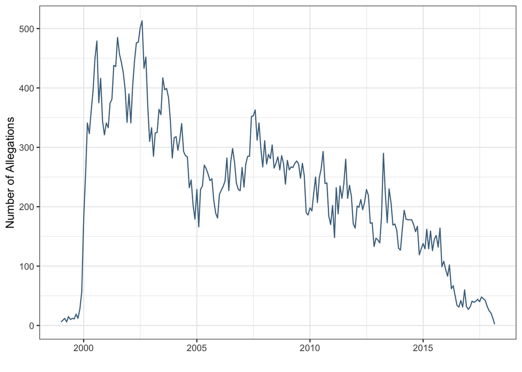

```r
allegations %>%
  filter(IncidentDate>=as.Date("1999-01-01")) %>%
  count(Date = factor(IncidentDate)) %>%
  ggplot(aes(x=as.Date(Date),y=n))+
  geom_line(color="skyblue4")+
  theme_bw()+
  labs(x ="", y = "Number of Allegations")
```

It has a downward trend and has a drop in 2005 and 2016.

## Most frequent allegation categories

This next plot presents the most frequent allegation category by finding.

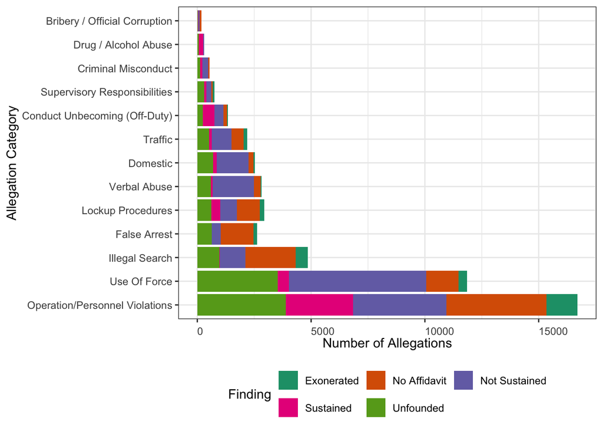

```r
allegations %>%
  filter(Finding!="Unknown") %>%
  count(Category = Category, Finding = Finding) %>%
  filter(n>=15) %>%
  ggplot(aes(x=reorder(Category,-n),y=n,fill=Finding))+
  geom_bar(stat = "identity")+
  theme_bw()+
  labs(x ="Allegation Category", y = "Number of Allegations")+coord_flip()+
  scale_fill_brewer(palette="Dark2")+
  guides(fill=guide_legend(nrow=2,byrow=TRUE))+
  theme(axis.text.x = element_text(angle = 0, vjust = 0, hjust=0),legend.position = "bottom")
```

The most frequent category is **Operation/Personnel Violations**. However, those allegations may be *sustained*, *not sustained*, *unfounded*, *exonerated*, or the allegation might be filed with *no affidavit*.

## Most frequent allegation type

The following represents the most frequent allegation type of served in the data.

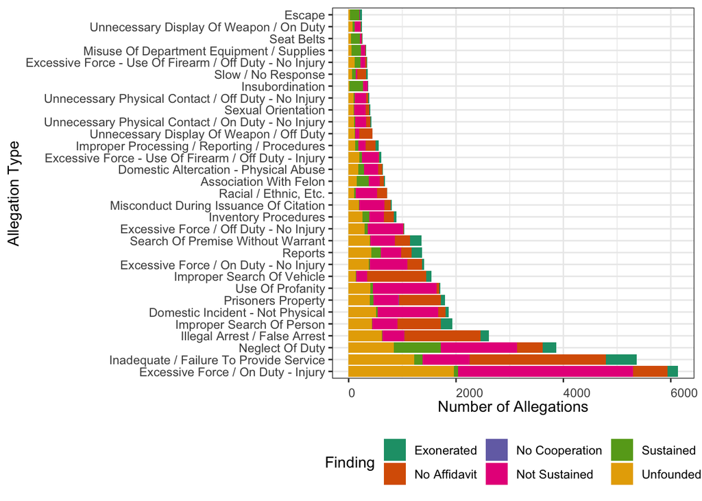

```r
allegations %>%
  filter(Finding!="Unknown"&Allegation!="Miscellaneous") %>%
  count(Allegation = Allegation, Category = Category) %>%
  filter(n>=230) %>%
  arrange(desc(n)) -> tmp

merge(tmp[,-3],
allegations %>%
  filter(Finding!="Unknown"&Allegation!="Miscellaneous") %>%
  count(Finding = Finding, Allegation = Allegation),
by="Allegation",all.x = T,all.y = F) %>%
  ggplot(aes(x=factor(Allegation,levels = tmp$Allegation),y=n,fill=Finding))+
  geom_bar(stat = "identity")+ #facet_wrap(~District,nrow=4)+
  theme_bw()+
  labs(x ="Allegation Type", y = "Number of Allegations")+coord_flip()+
  scale_fill_brewer(palette="Dark2")+
  theme(axis.text.x = element_text(angle = 0, vjust = 0, hjust=0),legend.position = "bottom")
```

## Final outcome and finding

Now, let’s explore final outcome for allegations recorded in the data. The outcome-axis is order in frequency, so that *No Action Taken* is the most frequent.

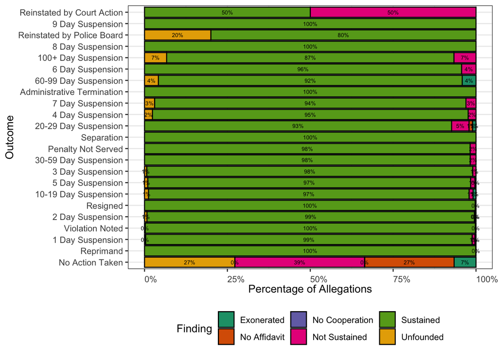

```r
allegations %>%
  filter(Outcome!="Unknown"&
           Finding!="Unknown") %>%
  count(Outcome = factor(Outcome),Finding = factor(Finding))%>%
  group_by(Outcome) %>%
  mutate(pct = prop.table(n)) %>%
  ggplot(aes(x=factor(Outcome,level=levels(forcats::fct_infreq(allegations$Outcome))),y=pct,fill=Finding))+
  geom_bar(position = "fill", stat = "identity",color='black',width=0.9) +
  scale_y_continuous(labels = scales::percent) +
  geom_text(aes(label = paste0(round(pct*100,0),"%")),position = position_stack(vjust = 0.5), size = 2)+
  theme_bw() + scale_fill_brewer(palette="Dark2")+
  labs(x ="Outcome", y = "Percentage of Allegations")+ coord_flip()+
  theme(legend.position="bottom") + theme(axis.text.x = element_text(angle = 0, vjust = 0, hjust=0))
```

## Interaction under investigation

### Race interacion frequency

Now let’s dig into the characteristics of the interaction in the data. This following graph shows the race of the officer and the race of the complaining witness.

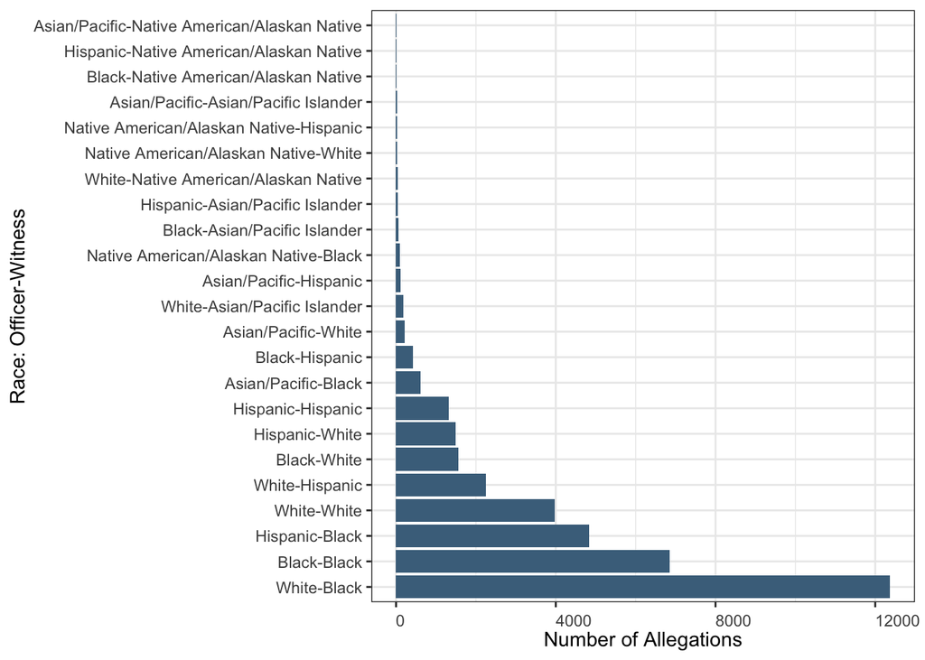

```r
all %>%
  filter(Outcome!="Unknown"&
           WitnessRace!="No Info"&
           OfficerRace!="Unknown"&
           Finding!="Unknown") %>%
  mutate(Int = paste0(OfficerRace,"-",WitnessRace)) %>%
  count(Int = Int) %>%
  ggplot(aes(x=reorder(Int,-n),y=n))+
  geom_bar(stat = "identity",fill="skyblue4")+
  theme_bw()+
  labs(x ="Race: Officer-Witness", y = "Number of Allegations")+coord_flip()+
  scale_fill_brewer(palette="Dark2")+
  theme(axis.text.x = element_text(angle = 0, vjust = 0, hjust=0),legend.position = "bottom")
```

The most frequent allegation is that involving a **White officer** and a **Black witness**.

### Race interaction and finding

Let’s look into the finding of the investigation and the officer-witness race from the interaction. The race-axis in the following plot is sorted by how frequent it is (just like the plot above).

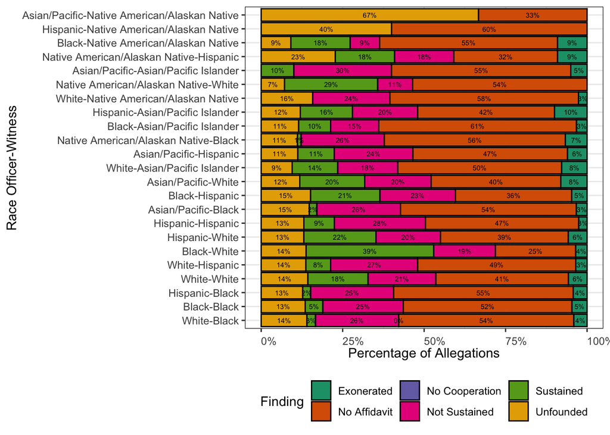

```r
all %>%
  filter(Outcome!="Unknown"&
           WitnessRace!="No Info"&
           OfficerRace!="Unknown"&
           Finding!="Unknown") %>%
  mutate(Int = paste0(OfficerRace,"-",WitnessRace)) %>%
  count(Int = factor(Int),Finding = factor(Finding))%>%
  group_by(Int) %>%
  mutate(pct = prop.table(n)) %>%
  ggplot(aes(x=factor(Int,level=levels(forcats::fct_infreq(paste0(all$OfficerRace,"-",all$WitnessRace)))),y=pct,fill=Finding))+
  geom_bar(position = "fill", stat = "identity",color='black',width=0.9) +
  scale_y_continuous(labels = scales::percent) +
  geom_text(aes(label = paste0(round(pct*100,0),"%")),position = position_stack(vjust = 0.5), size = 2)+
  theme_bw() + scale_fill_brewer(palette="Dark2")+
  labs(x ="Race Officer-Witness", y = "Percentage of Allegations")+ coord_flip()+
  theme(legend.position="bottom") + theme(axis.text.x = element_text(angle = 0, vjust = 0, hjust=0))
```

### Top 10 sustained allegations by race

This is definitely no proof that allegations filed by Black citizens are being neglected or disregarded. But it would be interesting to look into all the allegations for which the investigation found the allegation *Sustained*.

The following plots show the Top 10 *Sustained* allegations for Black and White citizens, separately.

#### Black witnesses

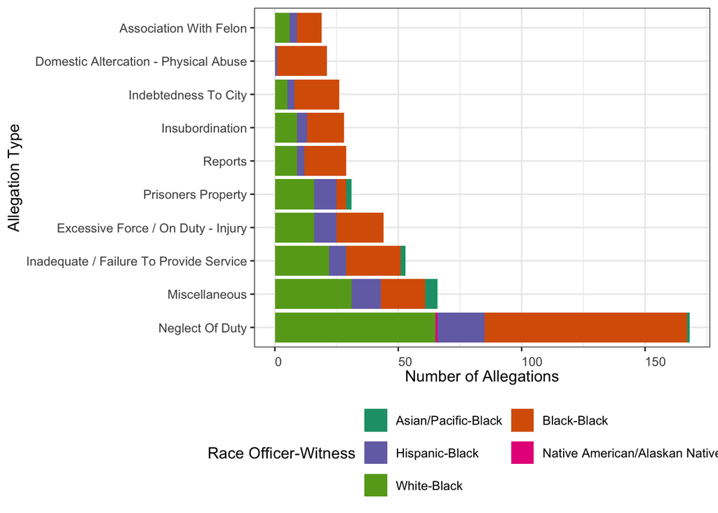

```r
a <- all %>%
  filter(Outcome!="Unknown"&
           WitnessRace=="Black"&
           OfficerRace!="Unknown"&
           Finding=="Sustained") %>%
  count(Allegation = factor(Allegation)) %>%
  arrange(desc(n)) %>%
  slice_head(n=10) #This is the top 10 for Black citizens

b <- all %>%
  filter(Outcome!="Unknown"&
           WitnessRace=="Black"&
           OfficerRace!="Unknown"&
           Finding=="Sustained") %>%
  mutate(Int = paste0(OfficerRace,"-",WitnessRace)) %>%
  count(WitnessRace = factor(WitnessRace),Int = factor(Int),Allegation = factor(Allegation))

c <- merge(a,b,by="Allegation",all.x = T,all.y = F)


c %>%
  ggplot(aes(x=factor(Allegation,levels = c(as.character(a$Allegation))),y=n.y,fill=Int))+
  geom_bar(stat = "identity") +
  theme_bw() + scale_fill_brewer(palette="Dark2")+
  labs(x ="Allegation Type", y = "Number of Allegations",fill="Race Officer-Witness")+ coord_flip()+
  guides(fill=guide_legend(nrow=3,byrow=TRUE))+
  theme(legend.position="bottom") + theme(axis.text.x = element_text(angle = 0, vjust = 0, hjust=0))
```

The most frequent *Sustained* allegation is **Neglect Of Duty** and **Excessive Force with Injury** is fourth.

#### White witnesses

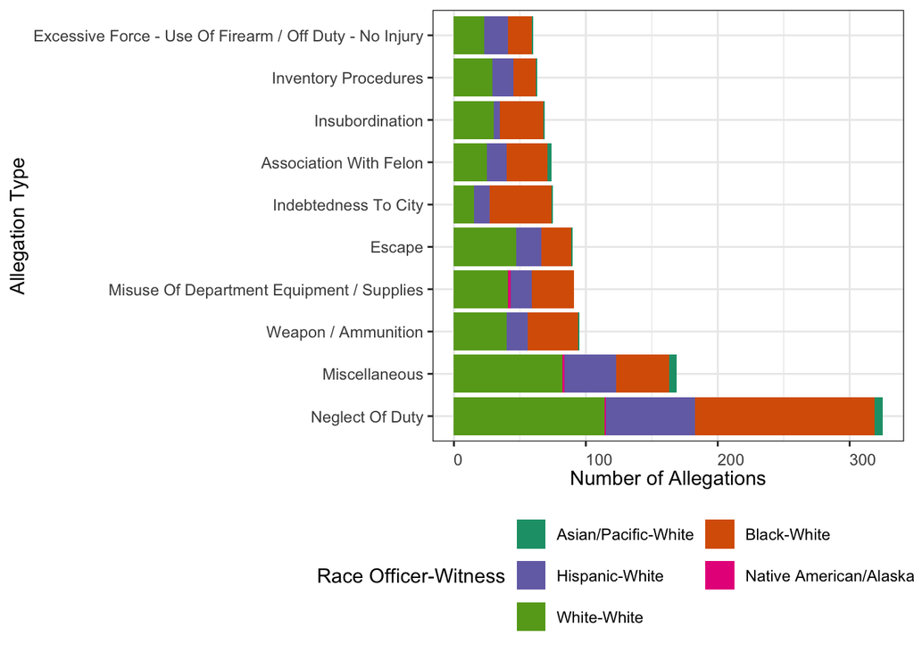

```r
a <- all %>%
  filter(Outcome!="Unknown"&
           WitnessRace=="White"&
           OfficerRace!="Unknown"&
           Finding=="Sustained") %>%
  count(Allegation = factor(Allegation)) %>%
  arrange(desc(n)) %>%
  slice_head(n=10) #This is the top 10 for White citizens

b <- all %>%
  filter(Outcome!="Unknown"&
           WitnessRace=="White"&
           OfficerRace!="Unknown"&
           Finding=="Sustained") %>%
  mutate(Int = paste0(OfficerRace,"-",WitnessRace)) %>%
  count(WitnessRace = factor(WitnessRace),Int = factor(Int),Allegation = factor(Allegation))

c <- merge(a,b,by="Allegation",all.x = T,all.y = F)


c %>%
  ggplot(aes(x=factor(Allegation,levels = c(as.character(a$Allegation))),y=n.y,fill=Int))+
  geom_bar(stat = "identity") +
  theme_bw() + scale_fill_brewer(palette="Dark2")+
  labs(x ="Allegation Type", y = "Number of Allegations",fill="Race Officer-Witness")+ coord_flip()+
  guides(fill=guide_legend(nrow=3,byrow=TRUE))+
  theme(legend.position="bottom") + theme(axis.text.x = element_text(angle = 0, vjust = 0, hjust=0))
```

The most frequent *Sustained* allegation is **Neglect Of Duty**. Although **Excessive Force with Injury** is not in the Top 10, White witnesses file more allegations that are *Sustained*.

# Random Forest Model

Now, I am going to grow a random forest model in order to predict whether an allegation is going to end up in a sustained finding or not.

The first that I will do is to split the sample into two groups: the training set and the validation set. I will utilize the training set to grow the model and the validation set to determine the accuracy of the model.

```r
set.seed(100)
train <- sample(nrow(data.rf), 0.7*nrow(data.rf), replace = FALSE)
TrainSet <- data.rf[train,]
ValidSet <- data.rf[-train,]
summary(TrainSet)
```

```
##                            Category                     Finding
##  Operation/Personnel Violations:18840   Other Than Sustained:53629
##  Use Of Force                  :14167   Sustained           : 4724
##  Illegal Search                : 6861
##  False Arrest                  : 4209
##  Lockup Procedures             : 3982
##  Verbal Abuse                  : 2834
##  (Other)                       : 7460
##              Outcome         District     officers_involved DistrictsWorked
##  No Action Taken :53534   11     : 4493   Min.   : 1.000    Min.   : 1.000
##  Reprimand       : 1226   7      : 4217   1st Qu.: 1.000    1st Qu.: 2.000
##  1 Day Suspension:  899   8      : 3582   Median : 2.000    Median : 3.000
##  Violation Noted :  480   9      : 3568   Mean   : 2.624    Mean   : 3.711
##  2 Day Suspension:  354   6      : 3547   3rd Qu.: 3.000    3rd Qu.: 5.000
##  Resigned        :  336   4      : 3357   Max.   :64.000    Max.   :15.000
##  (Other)         : 1524   (Other):35589
##  OfficerGender                         OfficerRace        Rank
##  F: 8302       Asian/Pacific                 : 1261   Length:58353
##  M:50051       Black                         :14743   Class :character
##                Hispanic                      :11087   Mode  :character
##                Native American/Alaskan Native:  180
##                White                         :31082
##
##
##    OfficerAge    officers_witness  WitnessGender
##  Min.   :26.00   Min.   : 0.0000   F      :10785
##  1st Qu.:46.00   1st Qu.: 0.0000   M      :16608
##  Median :51.00   Median : 0.0000   No Info:30960
##  Mean   :52.18   Mean   : 0.4603
##  3rd Qu.:58.00   3rd Qu.: 0.0000
##  Max.   :98.00   Max.   :99.0000
##
##                          WitnessRace     comp_witness    IncidentDaysAfterAppt
##  Asian/Pacific Islander        :  229   Min.   :0.0000   Min.   :    1
##  Black                         :17392   1st Qu.:0.0000   1st Qu.: 1563
##  Hispanic                      : 2927   Median :0.0000   Median : 2892
##  Native American/Alaskan Native:   43   Mean   :0.5119   Mean   : 3620
##  No Info                       :32770   3rd Qu.:1.0000   3rd Qu.: 5059
##  White                         : 4992   Max.   :3.0000   Max.   :20637
##
##  allegation_count AllegationType
##  Min.   : 1.000   2      :28428
##  1st Qu.: 2.000   25     :11061
##  Median : 4.000   37     : 7464
##  Mean   : 6.458   4      : 3696
##  3rd Qu.: 8.000   5      : 2271
##  Max.   :70.000   16     : 1719
##                   (Other): 3714
```

```r
summary(ValidSet)
```

```
##                            Category                    Finding
##  Operation/Personnel Violations:8238   Other Than Sustained:22907
##  Use Of Force                  :5929   Sustained           : 2102
##  Illegal Search                :3014
##  False Arrest                  :1785
##  Lockup Procedures             :1743
##  Verbal Abuse                  :1189
##  (Other)                       :3111
##              Outcome         District     officers_involved DistrictsWorked
##  No Action Taken :22878   11     : 1949   Min.   : 1.000    Min.   : 1.00
##  Reprimand       :  591   7      : 1805   1st Qu.: 1.000    1st Qu.: 2.00
##  1 Day Suspension:  402   9      : 1537   Median : 2.000    Median : 3.00
##  Violation Noted :  216   6      : 1512   Mean   : 2.613    Mean   : 3.72
##  2 Day Suspension:  156   8      : 1493   3rd Qu.: 3.000    3rd Qu.: 5.00
##  Resigned        :  146   4      : 1459   Max.   :64.000    Max.   :15.00
##  (Other)         :  620   (Other):15254
##  OfficerGender                         OfficerRace        Rank
##  F: 3639       Asian/Pacific                 :  524   Length:25009
##  M:21370       Black                         : 6298   Class :character
##                Hispanic                      : 4698   Mode  :character
##                Native American/Alaskan Native:   98
##                White                         :13391
##
##
##    OfficerAge    officers_witness  WitnessGender
##  Min.   : 27.0   Min.   : 0.0000   F      : 4567
##  1st Qu.: 46.0   1st Qu.: 0.0000   M      : 7072
##  Median : 51.0   Median : 0.0000   No Info:13370
##  Mean   : 52.3   Mean   : 0.4756
##  3rd Qu.: 58.0   3rd Qu.: 0.0000
##  Max.   :100.0   Max.   :99.0000
##
##                          WitnessRace     comp_witness    IncidentDaysAfterAppt
##  Asian/Pacific Islander        :   81   Min.   :0.0000   Min.   :   30
##  Black                         : 7346   1st Qu.:0.0000   1st Qu.: 1585
##  Hispanic                      : 1185   Median :0.0000   Median : 2928
##  Native American/Alaskan Native:   14   Mean   :0.5081   Mean   : 3654
##  No Info                       :14130   3rd Qu.:1.0000   3rd Qu.: 5097
##  White                         : 2253   Max.   :4.0000   Max.   :22110
##
##  allegation_count AllegationType
##  Min.   : 1.000   2      :12190
##  1st Qu.: 2.000   25     : 4721
##  Median : 4.000   37     : 3255
##  Mean   : 6.441   4      : 1573
##  3rd Qu.: 9.000   5      : 1007
##  Max.   :67.000   16     :  731
##                   (Other): 1532
```

```r
table(TrainSet$Finding)
```

```
##
## Other Than Sustained            Sustained
##                53629                 4724
```

To balance the training sample, I am going to randomly draw the observations from each category.

```r
#Balance Train set
cat <- as.character(data.frame(table(TrainSet$Finding))$Var1)
num <- min(data.frame(table(TrainSet$Finding))$Freq)

tmp <- NULL
for(i in 1:length(cat)){
  a <- TrainSet[which(TrainSet$Finding==cat[i]),]
  a <- a[sample(nrow(a),num, replace = FALSE),]
  tmp <- rbind(tmp,a)
}
TrainSet <- tmp
rm(tmp,a,cat,num,i)
```

Now we are good to proceed to grow the random forest. In this case I’m going to contact a classification exercise rather than a regression.

```r
model1 <- randomForest(Finding ~ . -Outcome, data = TrainSet, importance = TRUE, proximity = TRUE, do.trace = 100)
```

```
## ntree      OOB      1      2
##   100:  20.95% 24.24% 17.65%
##   200:  20.21% 23.07% 17.34%
##   300:  20.29% 23.16% 17.42%
##   400:  20.26% 23.14% 17.38%
##   500:  20.22% 23.31% 17.13%
```

```r
model1
```

```
##
## Call:
##  randomForest(formula = Finding ~ . - Outcome, data = TrainSet,      importance = TRUE, proximity = TRUE, do.trace = 100)
##                Type of random forest: classification
##                      Number of trees: 500
## No. of variables tried at each split: 3
##
##         OOB estimate of  error rate: 20.22%
## Confusion matrix:
##                      Other Than Sustained Sustained class.error
## Other Than Sustained                 3623      1101   0.2330652
## Sustained                             809      3915   0.1712532
```

```r
model1
```

```
##
## Call:
##  randomForest(formula = Finding ~ . - Outcome, data = TrainSet,      importance = TRUE, proximity = TRUE, do.trace = 100)
##                Type of random forest: classification
##                      Number of trees: 500
## No. of variables tried at each split: 3
##
##         OOB estimate of  error rate: 20.22%
## Confusion matrix:
##                      Other Than Sustained Sustained class.error
## Other Than Sustained                 3623      1101   0.2330652
## Sustained                             809      3915   0.1712532
```

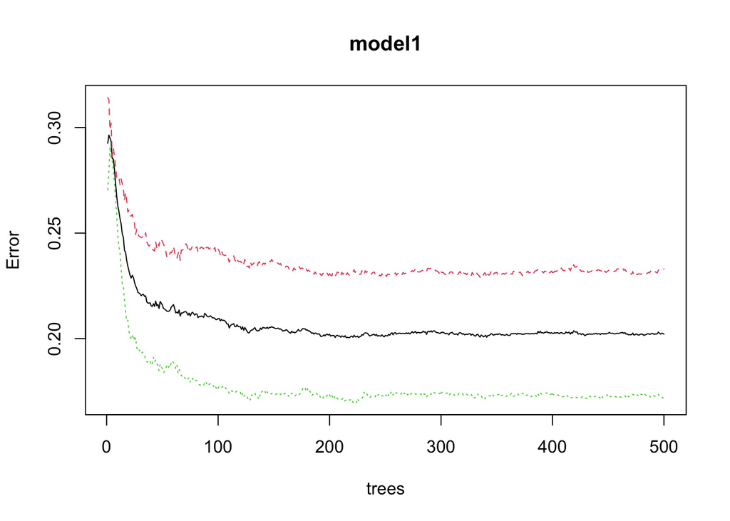

```r
plot(model1)
```

Normally what I would do with this type of models is to fine-tuning the parameters of the model. The two parameters to tune in the random forests are the number of trees grown (`ntree`) and the number of variables randomly sampled as candidates at each split (`mtry`). I will not present here all the different options that I tried. I will just stick to this model which seemed to be the best one. Note that the out-of-the-bag (OOB) error rate in this model is about 20%, which is not the best for a model of this kind. These means that the model is wrong 20% of the times that the it is evaluated in an out-of-the-bag sample.

Now, let’s see how the model behaves when predicting using the validation sample

```r
resultdt <- predict(model1, newdata = ValidSet, type = "class")

# Confusion matrix
cm <- table(ValidSet$Finding, resultdt, dnn = c("Actual", "Predicted"))
cm
```

```
##                       Predicted
## Actual                 Other Than Sustained Sustained
##   Other Than Sustained                17609      5298
##   Sustained                             327      1775
```

```r
accuracydt <- sum(diag(cm)) / sum(cm)
accuracydt
```

```
## [1] 0.775081
```

This model is able to correctly identify 77% of the cases evaluated in the validation set.

Now, let’s look at the importance of the variables that were included in the classification random forest.

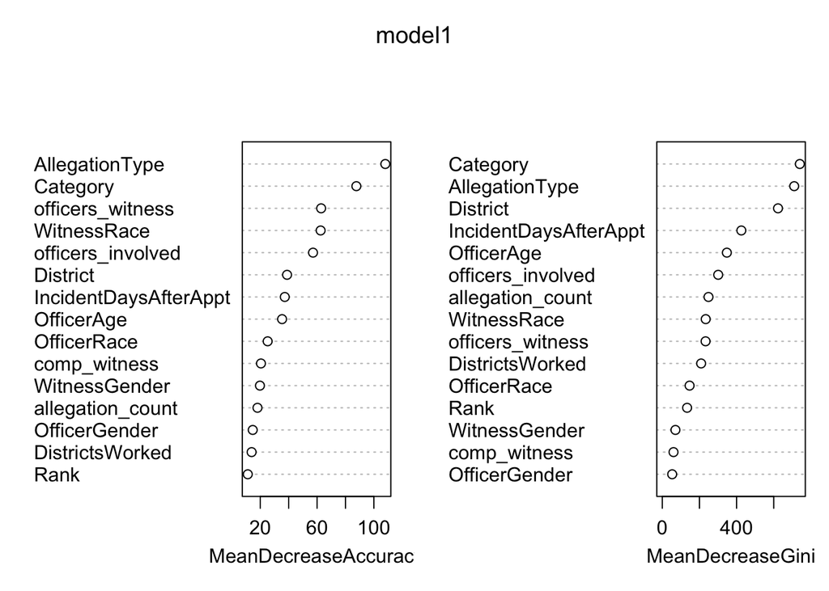

```r
varImpPlot(model1)
```

It looks like allegation type and allegation category are the two most important variables to predict whether a result of an investigation is going to be sustained or not.